# 02 Analysis — Spatial Equity of Social Infrastructure in Aarhus

# Purpose

Catchments, point-pattern analysis, spatial autocorrelation, a MAUP check, and the interactive Leaflet product. Reads only from `data/processed/` — no internet or API token needed. Take that folder from the GitHub Release and this script runs offline.

Expensive steps (network build, network distances) are cached to disk and skipped on reruns.

```r
library(pacman)
p_load(sf, tidyverse, here, units, sfnetworks, tidygraph,
       spatstat, spdep, tmap, mapview, leaflet, htmltools, htmlwidgets,
       ggrepel, scales)

crs_dk <- 25832
fs::dir_create(here("output/figures")); fs::dir_create(here("output/maps"))
fig_dir <- here("output/figures")   # explicit saves go here (robust across tmap/ggplot/base)

cache_rds <- function(path, compute) {
  if (file.exists(path)) return(readRDS(path))
  obj <- compute(); saveRDS(obj, path); obj
}
```

# 0. Load inputs

```r
aarhus_mun     <- readRDS(here("data/processed/aarhus_mun.rds"))
districts      <- readRDS(here("data/processed/districts.rds"))
kontur_aarhus  <- readRDS(here("data/processed/kontur_aarhus.rds"))
pois           <- readRDS(here("data/processed/pois.rds"))
parks_polygons <- readRDS(here("data/processed/parks_polygons.rds"))
walk_network   <- sfarrow::st_read_parquet(here("data/processed/aarhus_walk_network.parquet"))

nonpark_categories <- setdiff(unique(pois$category), "park")

# All inputs must be EPSG:25832
stopifnot(all(c(st_crs(aarhus_mun)$epsg, st_crs(kontur_aarhus)$epsg,
                st_crs(pois)$epsg, st_crs(walk_network)$epsg) == crs_dk))
```

For non-park categories distance is to the POI point; for parks it is the shortest distance to the park boundary, with hexes whose centroid lies inside a park set to 0.

# 1. Routable walking network

Largest connected component only, so orphaned fragments don’t create infinite distances.

```r
network_main <- cache_rds(here("data/processed/network_main.rds"), function() {
  walk_lines <- walk_network %>%
    st_cast("MULTILINESTRING") %>% st_cast("LINESTRING") %>%
    st_make_valid() %>% filter(!st_is_empty(geometry))

  net <- as_sfnetwork(walk_lines, directed = FALSE) %>%
    convert(to_spatial_subdivision, .clean = TRUE) %>%
    convert(to_spatial_smooth,      .clean = TRUE) %>%
    activate("edges") %>% mutate(weight = edge_length())

  comps   <- net %>% activate("nodes") %>% mutate(comp = group_components()) %>%
    as_tibble() %>% pull(comp)
  biggest <- as.integer(names(which.max(table(comps))))
  net %>% activate("nodes") %>% filter(group_components() == biggest)
})

nodes_main <- network_main %>% activate("nodes") %>% st_as_sf()
cat("Network nodes (largest component):", nrow(nodes_main), "\n")
```

```
Network nodes (largest component): 83019
```

```r
# How far are non-park POIs from the nearest network node?
pois_nonpark <- pois %>% filter(category != "park")
snap_dist <- as.numeric(st_distance(
  pois_nonpark, nodes_main[st_nearest_feature(pois_nonpark, nodes_main), ],
  by_element = TRUE))

tibble(category = pois_nonpark$category, snap_m = snap_dist) %>%
  group_by(category) %>%
  summarise(median_snap = round(median(snap_m), 1),
            n_far_off   = sum(snap_m > 100), .groups = "drop")
```

```
# A tibble: 4 × 3
  category         median_snap n_far_off
  <chr>                  <dbl>     <int>
1 cafe                    17.1         1
2 community_centre        18.7         0
3 fitness_centre          19.6         0
4 library                 17.5         0
```

# 2. Euclidean catchments (baseline)

One unioned polygon per (category, distance). Non-park: buffer the points; park: buffer the polygons.

```r
distances_m <- c(400, 800)

catchments_eucl <- cache_rds(here("data/processed/catchments_eucl.rds"), function() {
  eucl_point <- function(cat, d) {
    pois %>% filter(category == cat) %>% st_buffer(d) %>% st_union() %>%
      st_intersection(aarhus_mun) %>%
      st_sf(category = cat, distance_m = d, method = "euclidean", geometry = .)
  }
  eucl_park <- function(d) {
    parks_polygons %>% st_buffer(d) %>% st_union() %>%
      st_intersection(aarhus_mun) %>%
      st_sf(category = "park", distance_m = d, method = "euclidean", geometry = .)
  }
  nonpark <- tidyr::crossing(category = nonpark_categories, distance_m = distances_m) %>%
    pmap_dfr(function(category, distance_m) eucl_point(category, distance_m))
  park <- map_dfr(distances_m, eucl_park)
  bind_rows(nonpark, park)
})

mapview(filter(catchments_eucl, distance_m == 800), zcol = "category",
        alpha.regions = 0.3, layer.name = "800 m Euclidean catchments")
```

[interactive chart not shown]

# 3. Network distances and coverage flags

Hex centroids are the demand points (a 400 m hex holds people up to ~230 m from its centroid — noted as a resolution limit).

```r
# hex_id = row order of kontur_aarhus; every downstream join reuses this order,
# so kontur_aarhus must not be re-sorted.
hex_pts <- kontur_aarhus %>% st_centroid() %>%
  mutate(hex_id = row_number()) %>%
  select(hex_id, h3, population, distrikt)
```

## 3a. Non-park categories — distance to the nearest POI point

```r
nearest_nonpark <- cache_rds(here("data/processed/hex_nearest_poi_nonpark.rds"), function() {
  nearest_dist <- function(cat) {
    pois_cat <- pois %>% filter(category == cat)
    cost <- st_network_cost(network_main, from = hex_pts, to = pois_cat,
                            weights = "weight") %>% drop_units()
    min_d <- apply(cost, 1, min, na.rm = TRUE)
    min_d[is.infinite(min_d)] <- NA_real_
    tibble(hex_id = hex_pts$hex_id, category = cat, dist_m = min_d)
  }
  map_dfr(nonpark_categories, nearest_dist)
})
```

## 3b. Parks — distance to the boundary, not a centre point

A park is an area, entered from its edge, so measuring distance to a single centre point would overstate how far people are from large parks. Instead each park boundary is sampled every ~30 m, the distance is the shortest network path to any of those edge points, and hexes whose centroid already sits inside a park are set to 0. The Euclidean catchments (§2) follow the same logic by buffering the polygons rather than points.

```r
nearest_park <- cache_rds(here("data/processed/hex_nearest_poi_park.rds"), function() {
  access_pts <- parks_polygons %>%
    mutate(park_id_src = row_number()) %>%
    st_boundary() %>% st_cast("LINESTRING", warn = FALSE) %>%
    group_by(park_id_src) %>% summarise(.groups = "drop") %>%
    st_line_sample(density = 1/30) %>% st_cast("POINT") %>% st_sf()

  cost_park <- st_network_cost(network_main, from = hex_pts, to = access_pts,
                               weights = "weight") %>% drop_units()
  min_park <- apply(cost_park, 1, min, na.rm = TRUE)
  min_park[is.infinite(min_park)] <- NA_real_
  min_park[lengths(st_intersects(hex_pts, parks_polygons)) > 0] <- 0

  tibble(hex_id = hex_pts$hex_id, category = "park", dist_m = min_park)
})

# Park-distance sanity: how reachable are parks?
park_d <- nearest_park$dist_m
cat("Hexes within 400 m of a park edge:", round(100 * mean(park_d < 400, na.rm = TRUE), 1), "%\n")
```

```
Hexes within 400 m of a park edge: 82 %
```

```r
cat("Hexes within 800 m of a park edge:", round(100 * mean(park_d < 800, na.rm = TRUE), 1), "%\n")
```

```
Hexes within 800 m of a park edge: 94.7 %
```

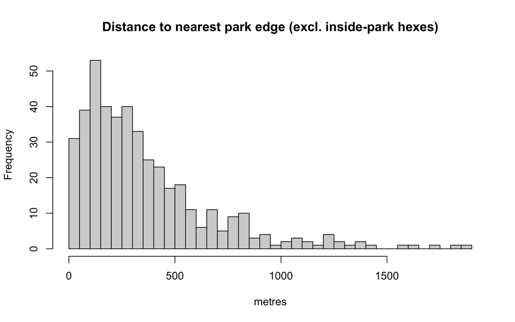

```r
hist(park_d[park_d > 0 & park_d < 2000], breaks = 50,
     main = "Distance to nearest park edge (excl. inside-park hexes)", xlab = "metres")
```

## 3c. Combine

```r
nearest_long <- cache_rds(here("data/processed/hex_nearest_poi.rds"), function() {
  bind_rows(nearest_nonpark, nearest_park)
})
```

```r
hex_coverage <- cache_rds(here("data/processed/hex_coverage.rds"), function() {
  nearest_wide <- nearest_long %>%
    pivot_wider(names_from = category, values_from = dist_m, names_prefix = "dist_")

  coverage <- nearest_wide %>%
    mutate(across(starts_with("dist_"),
                  list(`400` = ~ .x < 400, `800` = ~ .x < 800),
                  .names = "cov{.col}_{.fn}m")) %>%
    rename_with(~ str_replace(.x, "dist_", ""), .cols = starts_with("covdist_"))

  kontur_aarhus %>% mutate(hex_id = row_number()) %>%
    left_join(coverage, by = "hex_id")
})
```

# 4. Headline coverage (% population within reach)

```r
total_pop <- sum(hex_coverage$population, na.rm = TRUE)

coverage_summary <- hex_coverage %>% st_drop_geometry() %>%
  summarise(across(starts_with("cov"),
                   ~ sum(population[.x], na.rm = TRUE) / total_pop * 100)) %>%
  pivot_longer(everything(), names_to = "metric", values_to = "pct_pop_covered") %>%
  mutate(category   = str_extract(metric, "(?<=cov)[a-z_]+(?=_)"),
         distance_m = as.integer(str_extract(metric, "\\d+(?=m)")),
         pct_pop_covered = round(pct_pop_covered, 1)) %>%
  select(category, distance_m, pct_pop_covered) %>%
  arrange(category, distance_m)

coverage_summary
```

```
# A tibble: 10 × 3
   category         distance_m pct_pop_covered
   <chr>                 <int>           <dbl>
 1 cafe                    400            22.6
 2 cafe                    800            46.9
 3 community_centre        400            19.6
 4 community_centre        800            51.2
 5 fitness_centre          400            10.4
 6 fitness_centre          800            25.9
 7 library                 400             2.3
 8 library                 800            16.6
 9 park                    400            85.3
10 park                    800            98.7
```

```r
hex_pts_pop <- kontur_aarhus %>% st_centroid() %>%
  mutate(hex_id = row_number()) %>% select(hex_id, population)

eucl_cov <- catchments_eucl %>% group_split(category, distance_m) %>%
  map_dfr(function(s) {
    inside <- st_intersects(hex_pts_pop, s, sparse = FALSE)[, 1]
    tibble(category = s$category, distance_m = s$distance_m,
           pct_pop_covered_eucl =
             round(100 * sum(hex_pts_pop$population[inside], na.rm = TRUE) / total_pop, 1))
  })

comparison <- coverage_summary %>%
  rename(pct_pop_covered_network = pct_pop_covered) %>%
  left_join(eucl_cov, by = c("category", "distance_m")) %>%
  mutate(diff_pp = pct_pop_covered_eucl - pct_pop_covered_network)

comparison
```

```
# A tibble: 10 × 5
   category       distance_m pct_pop_covered_netw…¹ pct_pop_covered_eucl diff_pp
   <chr>               <dbl>                  <dbl>                <dbl>   <dbl>
 1 cafe                  400                   22.6                 33.3  10.7
 2 cafe                  800                   46.9                 64.3  17.4
 3 community_cen…        400                   19.6                 32    12.4
 4 community_cen…        800                   51.2                 68.1  16.9
 5 fitness_centre        400                   10.4                 18     7.6
 6 fitness_centre        800                   25.9                 42.5  16.6
 7 library               400                    2.3                  7.5   5.2
 8 library               800                   16.6                 26.9  10.3
 9 park                  400                   85.3                 96    10.7
10 park                  800                   98.7                 99.6   0.900
# ℹ abbreviated name: ¹pct_pop_covered_network
```

# 5. Hex analysis variables

Composite count = number of categories reachable within 800 m network walk (0–5).

```r
composite <- nearest_long %>%
  pivot_wider(names_from = category, values_from = dist_m, names_prefix = "dist_") %>%
  mutate(composite_count = rowSums(across(starts_with("dist_"), ~ .x < 800), na.rm = TRUE))

hex_analysis <- cache_rds(here("data/processed/hex_analysis.rds"), function() {
  base <- hex_coverage %>% mutate(hex_id = row_number()) %>%
    select(hex_id, h3, population, distrikt, starts_with("cov")) %>%
    left_join(composite, by = "hex_id")

  # Euclidean coverage flags (centroid-in-catchment) so the map can toggle method
  hex_centroids <- base %>% st_centroid() %>% select(hex_id)
  eucl_flags <- catchments_eucl %>%
    mutate(grp = paste0("cov_", category, "_", distance_m, "_eucl")) %>%
    group_split(grp) %>%
    map_dfr(function(s) tibble(hex_id = hex_centroids$hex_id, grp = s$grp[1],
                               value = lengths(st_intersects(hex_centroids, s)) > 0)) %>%
    pivot_wider(names_from = grp, values_from = value)

  base %>% left_join(eucl_flags, by = "hex_id") %>%
    rename_with(~ str_replace(.x, "^cov([a-z_]+)_(\\d+)m$", "cov_\\1_\\2_net"),
                .cols = matches("^cov[a-z_]+_\\d+m$"))
})

hex_analysis %>% st_drop_geometry() %>% count(composite_count) %>%
  mutate(pct = round(100 * n / sum(n), 1))
```

```
  composite_count   n  pct
1               0  41  5.2
2               1 546 69.4
3               2 112 14.2
4               3  52  6.6
5               4  30  3.8
6               5   6  0.8
```

# 6. Point pattern analysis — do third places cluster more than people?

```r
win <- as.owin(aarhus_mun)
categories <- unique(pois$category)

build_ppp <- function(cat_name) {
  xy <- pois %>% filter(category == cat_name) %>% st_coordinates()
  ppp(xy[, "X"], xy[, "Y"], window = win, check = FALSE)
}
ppp_list <- setNames(lapply(categories, build_ppp), categories)
sapply(ppp_list, npoints)
```

```
            cafe community_centre   fitness_centre          library
             204              127               45               23
            park
             311
```

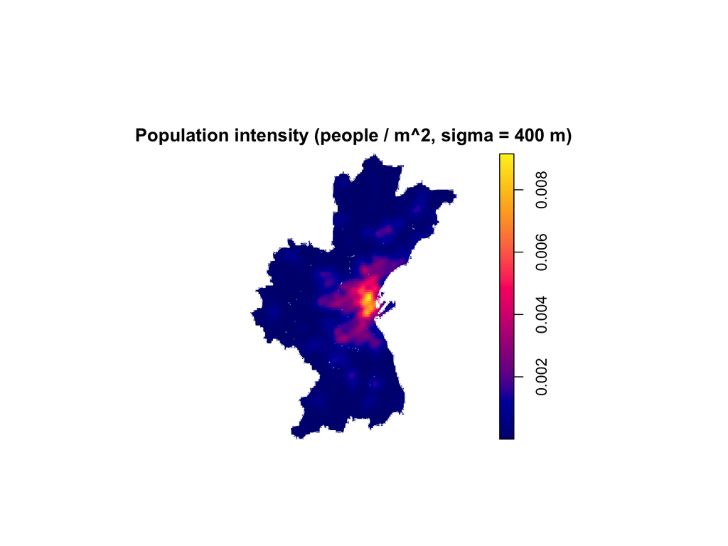

```r
# Population intensity surface (people/m^2), sigma = hex apothem
kontur_pp <- kontur_aarhus %>% st_centroid() %>%
  { ppp(st_coordinates(.)[, "X"], st_coordinates(.)[, "Y"],
        window = win, marks = .$population, check = FALSE) }
pop_im <- density(kontur_pp, weights = marks(kontur_pp), sigma = 400, edge = TRUE)

plot(pop_im, main = "Population intensity (people / m^2, sigma = 400 m)")
plot(aarhus_mun$geometry, add = TRUE, border = "white", lwd = 0.5)
```

A Poisson model `ppm(pp ~ pop_im)` fits log-intensity against population density; a positive coefficient means the category is preferentially located where people live.

```r
pop_vals <- as.numeric(pop_im$v); pop_vals <- pop_vals[is.finite(pop_vals)]
pop_z    <- (pop_im - mean(pop_vals)) / sd(pop_vals)

ppm_results <- cache_rds(here("data/processed/ppm_results.rds"), function() {
  res <- list()
  for (cat_name in categories) {
    pp <- ppp_list[[cat_name]]
    if (npoints(pp) >= 10) res[[cat_name]] <- ppm(pp ~ pop_z)
  }
  res
})

ppm_summary <- map_dfr(names(ppm_results), function(cat_name) {
  co <- summary(ppm_results[[cat_name]])$coefs.SE.CI
  z  <- co["pop_z", "Zval"]
  tibble(category           = cat_name,
         coef_pop_sd        = round(co["pop_z", "Estimate"], 3),
         rate_ratio_per_sd  = round(exp(co["pop_z", "Estimate"]), 2),
         z                  = round(z, 2),
         p_value            = signif(2 * (1 - pnorm(abs(z))), 3))
})
saveRDS(ppm_summary, here("data/processed/ppm_summary.rds"))
ppm_summary
```

```
# A tibble: 5 × 5
  category         coef_pop_sd rate_ratio_per_sd     z      p_value
  <chr>                  <dbl>             <dbl> <dbl>        <dbl>
1 cafe                   0.834              2.3  31.5  0
2 community_centre       0.56               1.75 16.1  0
3 fitness_centre         0.78               2.18 13.5  0
4 library                0.506              1.66  5.58 0.0000000241
5 park                   0.549              1.73 23.8  0
```

```r
# Negative (blue) = fewer POIs than population predicts -> relative under-supply
png(file.path(fig_dir, "ppm_residuals.png"), width = 12, height = 8,
    units = "in", res = 200)
par(mfrow = c(2, 3))
for (cat_name in names(ppm_results)) {
  plot(Smooth(residuals(ppm_results[[cat_name]], type = "raw"), sigma = 500),
       main = paste0("PPM residuals: ", cat_name))
  plot(aarhus_mun$geometry, add = TRUE, border = "white", lwd = 0.4)
}
par(mfrow = c(1, 1)); dev.off()
```

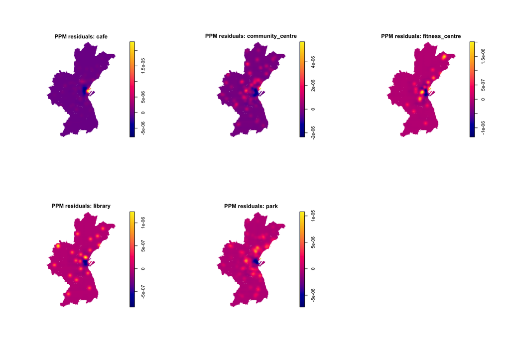

```r
knitr::include_graphics(file.path(fig_dir, "ppm_residuals.png"))
```

# 7. Spatial autocorrelation

```r
hex_w <- cache_rds(here("data/processed/hex_weights.rds"), function() {
  nb <- poly2nb(hex_analysis, queen = TRUE)
  list(nb = nb, lw = nb2listw(nb, style = "W", zero.policy = TRUE))
})
lw_hex <- hex_w$lw
cat("Hexes with zero neighbours:", sum(card(hex_w$nb) == 0), "\n")
```

```
Hexes with zero neighbours: 0
```

```r
moran_vars <- c("cov_park_800_net", "cov_library_800_net", "cov_cafe_800_net",
                "cov_fitness_centre_800_net", "cov_community_centre_800_net",
                "composite_count")

global_moran <- map_dfr(moran_vars, function(v) {
  vec <- as.numeric(hex_analysis[[v]]); vec[is.na(vec)] <- mean(vec, na.rm = TRUE)
  mc <- moran.mc(vec, lw_hex, nsim = 999, zero.policy = TRUE)
  tibble(variable = v, morans_I = round(as.numeric(mc$statistic), 3),
         p_MC = signif(mc$p.value, 3))
})
global_moran
```

```
# A tibble: 6 × 3
  variable                     morans_I  p_MC
  <chr>                           <dbl> <dbl>
1 cov_park_800_net                0.233 0.001
2 cov_library_800_net             0.198 0.001
3 cov_cafe_800_net                0.355 0.001
4 cov_fitness_centre_800_net      0.34  0.001
5 cov_community_centre_800_net    0.369 0.001
6 composite_count                 0.488 0.001
```

```r
# Variables are coverage flags / counts (high = well served), so no sign flip
# is needed: HH = covered-among-covered (well-served core); LL = gap-among-gaps
# (underserved cluster). FDR-corrected permutation LISA (Anselin 1995).
classify_lisa <- function(x, lw, alpha = 0.05) {
  x[is.na(x)] <- mean(x, na.rm = TRUE)
  lm_res <- localmoran_perm(x, lw, nsim = 999, zero.policy = TRUE)
  p_fdr <- p.adjust(lm_res[, "Pr(z != E(Ii))"], method = "fdr")
  z     <- as.numeric(scale(x))
  lag_z <- as.numeric(scale(lag.listw(lw, x, zero.policy = TRUE)))
  cluster <- case_when(
    p_fdr >= alpha      ~ "Not significant",
    z >= 0 & lag_z >= 0 ~ "High-High",
    z <  0 & lag_z <  0 ~ "Low-Low",
    z >= 0 & lag_z <  0 ~ "High-Low",
    z <  0 & lag_z >= 0 ~ "Low-High",
    TRUE                ~ "Not significant")
  factor(cluster, levels = c("High-High", "Low-Low", "High-Low",
                             "Low-High", "Not significant"))
}

hex_lisa <- cache_rds(here("data/processed/hex_lisa.rds"), function() {
  out <- hex_analysis
  for (v in moran_vars)
    out[[paste0("lisa_", v)]] <- classify_lisa(as.numeric(hex_analysis[[v]]), lw_hex)
  out
})
```

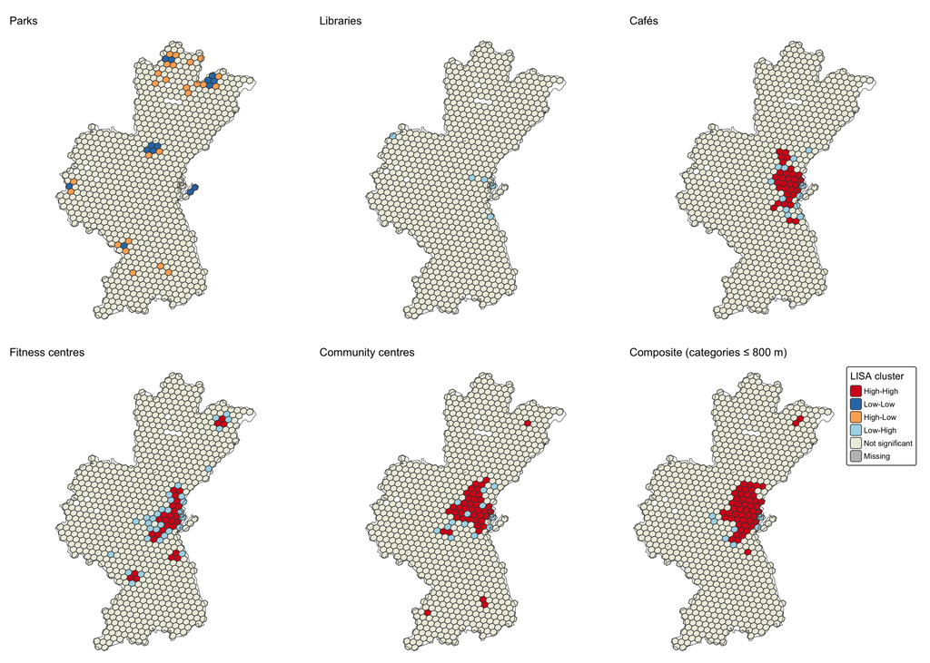

```r
tmap_mode("plot")
lisa_palette <- c("High-High" = "#d7191c", "Low-Low" = "#2c7bb6",
                  "High-Low" = "#fdae61", "Low-High" = "#abd9e9",
                  "Not significant" = "ivory2")
facet_vars   <- paste0("lisa_", moran_vars)
facet_labels <- c("Parks", "Libraries", "Cafés", "Fitness centres",
                  "Community centres", "Composite (categories ≤ 800 m)")

lisa_maps <- lapply(seq_along(facet_vars), function(i) {
  tm_shape(hex_lisa) +
    tm_polygons(facet_vars[i], palette = lisa_palette, border.col = NA,
                showNA = FALSE, title = "LISA cluster") +
    tm_shape(aarhus_mun) + tm_borders(col = "grey30", lwd = 0.7) +
    tm_layout(main.title = facet_labels[i], main.title.size = 1.0,
              legend.show = (i == length(facet_vars)), frame = FALSE)
})
lisa_facet <- do.call(tmap_arrange, c(lisa_maps, list(ncol = 3)))
tmap_save(lisa_facet, file.path(fig_dir, "lisa_facet.png"),
          width = 14, height = 10, dpi = 200)
```

```r
lisa_facet
```

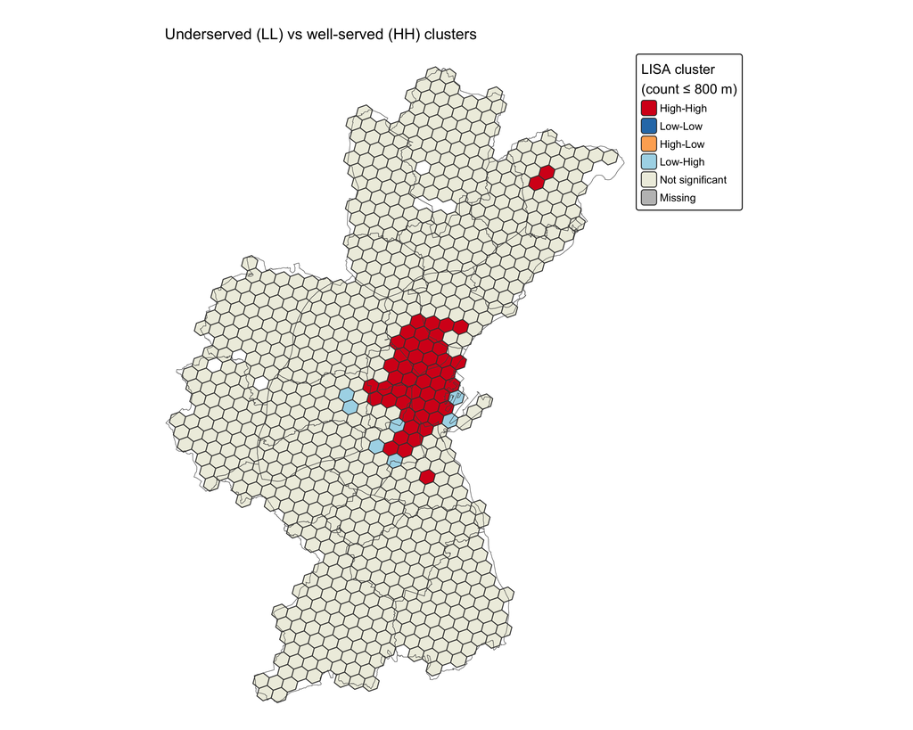

```r
lisa_headline <- tm_shape(hex_lisa) +
  tm_polygons("lisa_composite_count", palette = lisa_palette, border.col = NA,
              showNA = FALSE, title = "LISA cluster\n(count ≤ 800 m)") +
  tm_shape(districts) + tm_borders(col = "grey30", lwd = 0.5) +
  tm_layout(legend.outside = TRUE, frame = FALSE,
            main.title = "Underserved (LL) vs well-served (HH) clusters",
            main.title.size = 1.0)
tmap_save(lisa_headline, file.path(fig_dir, "lisa_headline.png"),
          width = 10, height = 8, dpi = 200)
```

```r
lisa_headline
```

# 8. Interactive coverage explorer (Leaflet product)

```r
hex_wgs    <- st_transform(hex_analysis, 4326)
parks_wgs  <- st_transform(parks_polygons, 4326)
pois_wgs   <- st_transform(pois, 4326)
aarhus_wgs <- st_transform(aarhus_mun, 4326)

cat_colors <- c(park = "#1a9850", library = "#984ea3", cafe = "#ff7f00",
                fitness_centre = "#e41a1c", community_centre = "#377eb8")
cat_labels <- c(park = "Parks", library = "Libraries", cafe = "Cafés",
                fitness_centre = "Fitness centres", community_centre = "Community centres")

# Composite count (network) at each distance
hex_wgs <- hex_wgs %>%
  mutate(n_400_net = rowSums(across(ends_with("_400_net")), na.rm = TRUE),
         n_800_net = rowSums(across(ends_with("_800_net")), na.rm = TRUE))

pal_count <- colorNumeric("YlGnBu", domain = 0:5, na.color = "#00000000")
```

```r
# Native Leaflet allows only one radio dimension, so distance is encoded in each
# layer's name. Tick a category to see the hexes it covers at that distance.
map <- leaflet(options = leafletOptions(minZoom = 10, preferCanvas = TRUE)) %>%
  addProviderTiles("CartoDB.Positron") %>%
  addPolygons(data = aarhus_wgs, fill = FALSE, color = "#222", weight = 1.5,
              group = "Aarhus boundary")

cov_groups <- character(0)

# Composite count (toggleable), one layer per distance
for (d in c(400, 800)) {
  g <- paste0("Categories covered ≤", d, " m"); col <- paste0("n_", d, "_net")
  map <- map %>% addPolygons(
    data = hex_wgs, group = g, fillColor = pal_count(hex_wgs[[col]]),
    fillOpacity = 0.7, stroke = FALSE,
    label = paste0(hex_wgs[[col]], " of 5 categories ≤", d, " m"))
  cov_groups <- c(cov_groups, g)
}

# Per-category covered hexes, one layer per (category, distance)
for (d in c(400, 800)) for (cat in names(cat_labels)) {
  col <- paste0("cov_", cat, "_", d, "_net")
  covered <- hex_wgs[which(hex_wgs[[col]]), ]
  if (nrow(covered) == 0) next
  g <- paste0(cat_labels[[cat]], " ≤", d, " m")
  map <- map %>% addPolygons(
    data = covered, group = g, fillColor = cat_colors[[cat]],
    fillOpacity = if (d == 400) 0.55 else 0.35, stroke = FALSE,
    smoothFactor = 0.3, label = g)
  cov_groups <- c(cov_groups, g)
}

map <- map %>%
  addCircleMarkers(data = pois_wgs, group = "Third places (points)",
    color = cat_colors[pois_wgs$category], radius = 3, stroke = FALSE,
    fillOpacity = 0.85, label = ~name) %>%
  addPolygons(data = parks_wgs, group = "Park polygons",
    fillColor = "#1a9850", fillOpacity = 0.25, color = "#1a9850", weight = 0.8) %>%
  addLayersControl(
    overlayGroups = c(cov_groups, "Third places (points)",
                      "Park polygons", "Aarhus boundary"),
    options = layersControlOptions(collapsed = TRUE)) %>%
  hideGroup(setdiff(c(cov_groups, "Third places (points)", "Park polygons"),
                    "Categories covered ≤800 m")) %>%
  addLegend(pal = pal_count, values = 0:5, opacity = 0.7,
            title = "Categories covered (0–5)", position = "bottomright")

saveWidget(map, here("output/maps/coverage_map.html"), selfcontained = TRUE)
map
```

[interactive chart not shown]

# 9. MAUP robustness — repeat at lokalsamfund scale

```r
agg_vars <- c("cov_park_800_net", "cov_library_800_net", "cov_cafe_800_net",
              "cov_fitness_centre_800_net", "cov_community_centre_800_net",
              "composite_count")

district_an <- cache_rds(here("data/processed/district_lisa.rds"), function() {
  dv <- hex_analysis %>% st_drop_geometry() %>% filter(!is.na(distrikt)) %>%
    group_by(distrikt) %>%
    summarise(across(all_of(agg_vars),
                     ~ weighted.mean(as.numeric(.x), w = population, na.rm = TRUE)),
              pop_total = sum(population, na.rm = TRUE), .groups = "drop")

  d <- districts %>% left_join(dv, by = "distrikt") %>%
    mutate(area_km2 = as.numeric(st_area(.)) / 1e6,
           pop_density = pop_total / area_km2)

  lw_d <- nb2listw(poly2nb(d, queen = TRUE), style = "W", zero.policy = TRUE)
  d %>% mutate(
    lisa_cov_park_800_net = classify_lisa(cov_park_800_net, lw_d),
    lisa_composite_count  = classify_lisa(composite_count, lw_d))
})

cat("Districts retained:", nrow(district_an), "\n")
```

```
Districts retained: 24
```

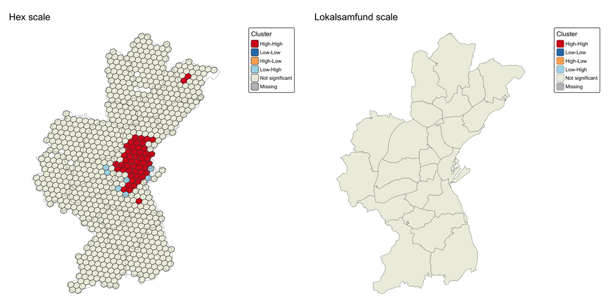

```r
m_hex <- tm_shape(hex_lisa) +
  tm_polygons("lisa_composite_count", palette = lisa_palette, border.col = NA,
              showNA = FALSE, title = "Cluster") +
  tm_shape(districts) + tm_borders(col = "grey40", lwd = 0.4) +
  tm_layout(main.title = "Hex scale", legend.outside = TRUE, frame = FALSE)
m_dist <- tm_shape(district_an) +
  tm_polygons("lisa_composite_count", palette = lisa_palette,
              border.col = "grey20", lwd = 0.4, showNA = FALSE, title = "Cluster") +
  tm_layout(main.title = "Lokalsamfund scale", legend.outside = TRUE, frame = FALSE)
maup_compare <- tmap_arrange(m_hex, m_dist, ncol = 2)
tmap_save(maup_compare, file.path(fig_dir, "maup_compare.png"),
          width = 14, height = 7, dpi = 200)
```

```r
maup_compare
```

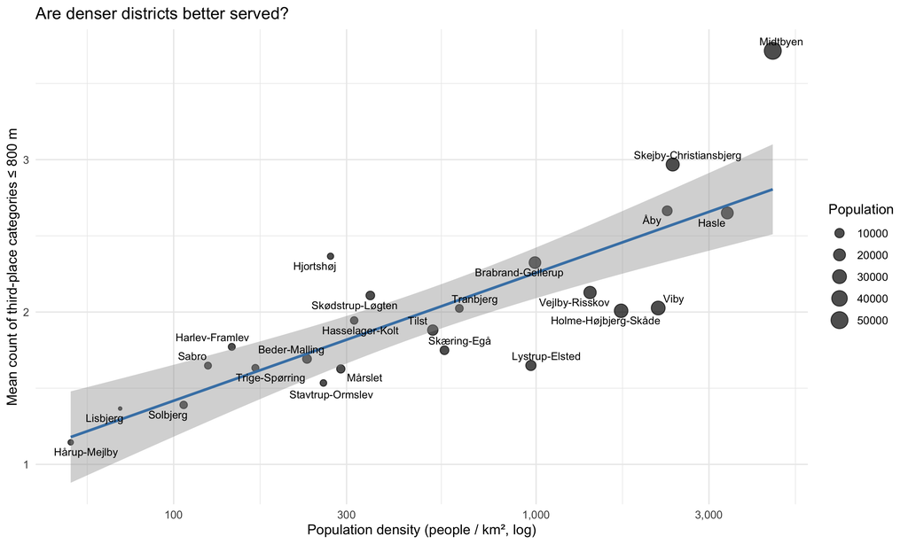

```r
scatter_plot <- district_an %>% st_drop_geometry() %>%
  ggplot(aes(pop_density, composite_count, label = distrikt)) +
  geom_point(aes(size = pop_total), alpha = 0.7) +
  geom_smooth(method = "lm", se = TRUE, colour = "steelblue") +
  geom_text_repel(size = 3, max.overlaps = 15) +
  scale_x_log10(labels = comma) +
  labs(x = "Population density (people / km², log)",
       y = "Mean count of third-place categories ≤ 800 m",
       size = "Population", title = "Are denser districts better served?") +
  theme_minimal()
ggsave(file.path(fig_dir, "pop_density_scatter.png"), scatter_plot,
       width = 10, height = 6, dpi = 200)
scatter_plot
```

# Outputs

| File | Description |
| --- | --- |
| `network_main.rds` | sfnetwork, largest component, metre edge weights |
| `catchments_eucl.rds` | 10 Euclidean catchment polygons |
| `hex_nearest_poi_nonpark.rds` | hex × non-park category → distance to nearest POI point (m) |
| `hex_nearest_poi_park.rds` | hex → distance to nearest park *edge* (m); inside-park = 0 |
| `hex_nearest_poi.rds` | the two combined |
| `hex_coverage.rds` | hexes + network coverage flags |
| `hex_analysis.rds` | hexes + composite + network & Euclidean flags |
| `hex_lisa.rds`, `district_lisa.rds` | LISA clusters at both scales |
| `ppm_summary.rds` | PPM coefficients per category |
| `output/maps/coverage_map.html` | interactive Leaflet product |